# Introduction to Double Constrained Correspondance Analysis

Frelat, R.

7th June 2021

**This document is a work in progress ! Use only with extreme care.**

This document provides an introduction to double constrained correspondence analysis (DC-CA). The tutorial targets students and scientists in ecology with previous knowledge of the [R software](https://cran.r-project.org/).

This tutorial is greatly inspired from the [tutorial by ter Braak C.J.F. et al. 2016](https://ars.els-cdn.com/content/image/1-s2.0-S0048969720357004-mmc4.pdf). Please read the original publication for more details about the double constrained correspondence analysis analysis [DOI 10.1016/j.scitotenv.2020.142171](https://doi.org/10.1016/j.scitotenv.2020.142171)

The example dataset is available for download [here ( NEAtl_FishTraitEnv.Rdata)](https://github.com/rfrelat/TraitEnvironment/raw/main/NEAtl_FishTraitEnv.Rdata) and the script [here (DCCA_FishTraitEnv.R)](https://github.com/rfrelat/TraitEnvironment/raw/main/DCCA_FishTraitEnv.R)

# 0. Preliminaries

### Load packages and dataset

The DC-CA analyses require the R packages [ade4 (v ≥ 1.7.16)](https://pbil.univ-lyon1.fr/ade4/home.php?lang=eng).

```r
library(ade4)
```

To plot maps with country border, you also need the packages `ggplot2 (v ≥ 3.3)`.

```r
library(ggplot2)
```

If you get an error message, check that the R packages are installed correctly. If not, use the command: `install.packages(c("ade4", "ggplot2"))`.

### Load the example dataset

```r
load("NEAtl_FishTraitEnv.Rdata")
```

The Rdata file contains four objects:

- `abu` containing the abundance of taxa in grid cells
- `env` containing the environmental condition per grid cell
- `trait` containing the trait information per taxa
- `coo`: the coordinates of each grid cell

Importantly, the rows in `abu` correspond to the same grid cell than the rows in `env`, and the column in `abu` correspond to the same taxa than the rows in `trait`.

```r
all(row.names(abu)==row.names(env))
```

```
## [1] TRUE
```

```r
all(colnames(abu)==row.names(trait))
```

```
## [1] TRUE
```

If you want to learn how to create such dataset, see the short [tutorial on setting trait-environement dataset](https://rfrelat.github.io/CleanDataTER.html).

Using the fish community of the Northeast Atlantic as an example, we will **explore the trait-environment relationship using the DC-CA analysis**.

### Quick summary of the variables

```r
dim(trait)
```

```
## [1] 148   7
```

```r
names(trait)
```

```
## [1] "Trophic.level"      "K"                  "Lmax"
## [4] "Lifespan"           "Age.maturity"       "Fecundity_log"
## [7] "Offspring.size_log"
```

The `trait` table contains 7 traits (i.e variable, in column) characterizing 148 taxa (in rows). The 7 traits broadly represent the life history and ecology of fish in terms of their feeding, growth, survival and reproduction. These are:

- Trophic level
- K: the growth rate, calculated as Von Bertalanffy growth coefficient in year$^{-1}$
- Lmax: maximum body length in cm
- Lifespan
- Offspring.size_log: egg diameter, length of egg case or length of pup in mm
- Fecundity_log: number of offspring produced by a female per year
- Age.maturity: in years

Trait values for fecundity and offspring size were log-transformed to reduce the influence of outliers.

```r
dim(env)
```

```
## [1] 169   7
```

```r
names(env)
```

```
## [1] "Depth"   "SBT"     "SBS"     "Chl"     "SBT_sea" "Chl_sea" "Fishing"
```

The `env` table contains 7 environmental variables (in column) characterizing 169 grid cells (in rows). The environmental variables measure hydrography, habitat, food availability and anthropogenic pressures, which are known to affect the distribution of fish species. These are:

- Depth: depth in meter, directly measured during the survey.
- SBT: monthly sea bottom temperature in °C from the Global Ocean Physics Reanalysis (GLORYSs2v4)
- SBS: monthly sea bottom salinity from the Global Ocean Physics Reanalysis (GLORYSs2v4)
- Chl: Chlorophyll a concentration (in $mg.m^{-3}$) as a proxy for primary production and food availability from the GlobColour database
- SBT_sea: seasonality of sea bottom temperature, calculated as the difference between the warmest and the coldest month of the year.
- Chl_sea: seasonality of chlorophyll a concentration, calculated as the difference between the highest and the lowest primary production in the year
- Fishing: the cumulative demersal fishing pressure in 2013, estimated globally by Halpern et al. 2015, [DOI 10.1038/ncomms8615](https://doi.org/10.1038/ncomms8615).

# 1. Fast DC-CA based on single SVD algorithm

## 1.2 Run DC-CA

In this first step, we use DC-CA based on single SVD algorithm. We need to set the scaling factor `alpha`, which can vary between 0 if focusing on species, or 1 if focusing on sites. We chose a balanced scaling of `alpha=0.5`.

```r
#alpha <- 0 # focus on species
#alpha <- 1 # focus on samples
alpha <- 0.5 # compromise scaling

dccaF<- dcCA(abu, env, trait, alpha=alpha)
```

As with RLQ analysis, the DCCA provide scores for species, sites, traits and environmental variables.

The eigen values are stored as `lambda` and the fourth corner correlation in `rho`.

```r
# dc-CA eigen values
dccaF$lambda
```

```
## [1] 0.1056964325 0.0720350676 0.0391484961 0.0111244967 0.0074539001
## [6] 0.0009150886 0.0003960238
```

```r
# fourth corner correlation
dccaF$rho
```

```
## [1] 0.32510988 0.26839349 0.19785979 0.10547273 0.08633597 0.03025043 0.01990035
```

```r
# Explained variance (cum)
round(cumsum(dccaF$lambda)*100,1)
```

```
## [1] 10.6 17.8 21.7 22.8 23.5 23.6 23.7
```

```r
# Explained fitted variation (cum.)
round(cumsum(dccaF$lambda)/sum(dccaF$lambda)*100, 1)
```

```
## [1]  44.6  75.1  91.6  96.3  99.4  99.8 100.0
```

The first axis explains 45% of covariance. In the next step, we will interpret the scores of the two first axis (but similar visualization could be carried out for subsequent axis).

## 1.2 Trait scores

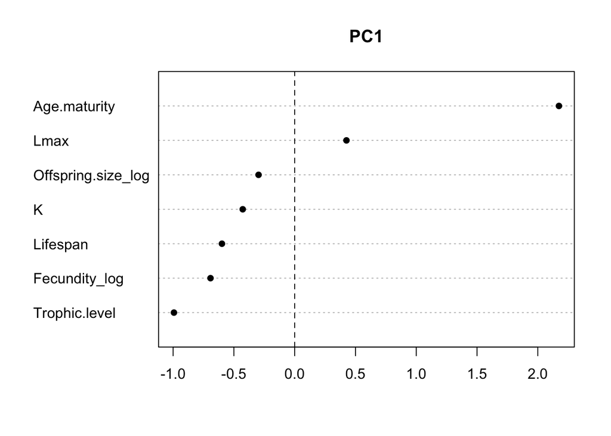

```r
#Plot traits score
t1 <- order(dccaF$C1[,1])
dotchart(dccaF$C1[t1,1], pch=16,
         labels = names(trait)[t1],
         main="PC1")
abline(v=0, lty=2)
```

## 1.3 Species scores

Due to the high number of species (`nrow(trait)`), it is hard to visualize the score of each individual species. But we can see the species with highest and lowest score on PC1.

```r
# top 10 species with positive score
top10 <- order(dccaF$U[,1], decreasing = TRUE)[1:10]
cbind(colnames(abu), dccaF$U[,1])[top10,]
```

```
##       [,1]                        [,2]
##  [1,] "Coelorinchus caelorhincus" "25.3255638950382"
##  [2,] "Dipturus batis"            "23.7822853099728"
##  [3,] "Macrourus berglax"         "23.6182155938579"
##  [4,] "Malacocephalus laevis"     "22.8886755784172"
##  [5,] "Helicolenus dactylopterus" "19.872108591811"
##  [6,] "Dipturus oxyrinchus"       "18.4559178961058"
##  [7,] "Chimaera monstrosa"        "17.3317751802556"
##  [8,] "Hippoglossus hippoglossus" "17.2101059525373"
##  [9,] "Amblyraja radiata"         "17.0809702686715"
## [10,] "Pleuronectes platessa"     "16.2343235052514"
```

```r
# top 10 species with negative score
top10 <- order(dccaF$U[,1])[1:10]
cbind(colnames(abu), dccaF$U[,1])[top10,]
```

```
##       [,1]                     [,2]
##  [1,] "Gasterosteus aculeatus" "-19.5822141459343"
##  [2,] "Echiichthys"            "-15.8390313930415"
##  [3,] "Merlangius merlangus"   "-12.1322092074775"
##  [4,] "Scophthalmus rhombus"   "-11.5648149357792"
##  [5,] "Trachinus draco"        "-11.1271198291644"
##  [6,] "Hyperoplus immaculatus" "-10.3636525445158"
##  [7,] "Alosa fallax"           "-9.47477548306718"
##  [8,] "Arnoglossus imperialis" "-9.16059601570448"
##  [9,] "Pagellus bogaraveo"     "-9.05353373177748"
## [10,] "Lepidorhombus boscii"   "-8.93188805548725"
```

## 1.4 Environmental scores

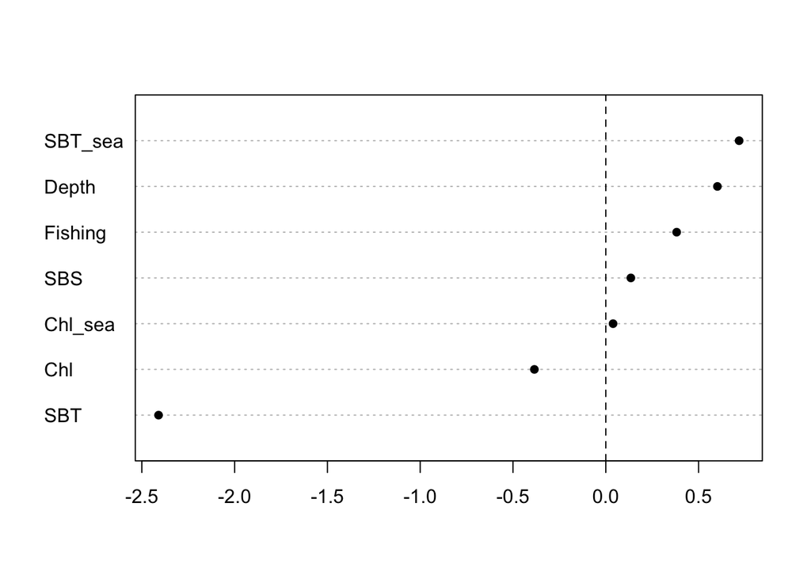

```r
#Plot environment score
e1 <- order(dccaF$B1[,1])
dotchart(dccaF$B1[e1,1], pch=16,
         labels = names(env)[e1])
abline(v=0, lty=2)
```

## 1.5 Sites scores

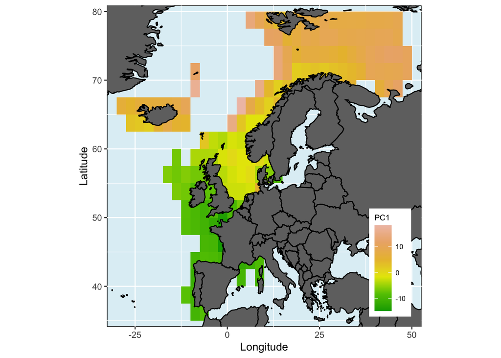

```r
# Choice of diverging color scale
colpal <- terrain.colors(7)[-7]
# or from RColorBrewer package
# colpal <- rev(RColorBrewer::brewer.pal(6,"RdYlBu"))

mapggplot(coo[,1], coo[,2], dccaF$X[,1],
          colpal, main="PC1")
```

## 1.6 Second axis

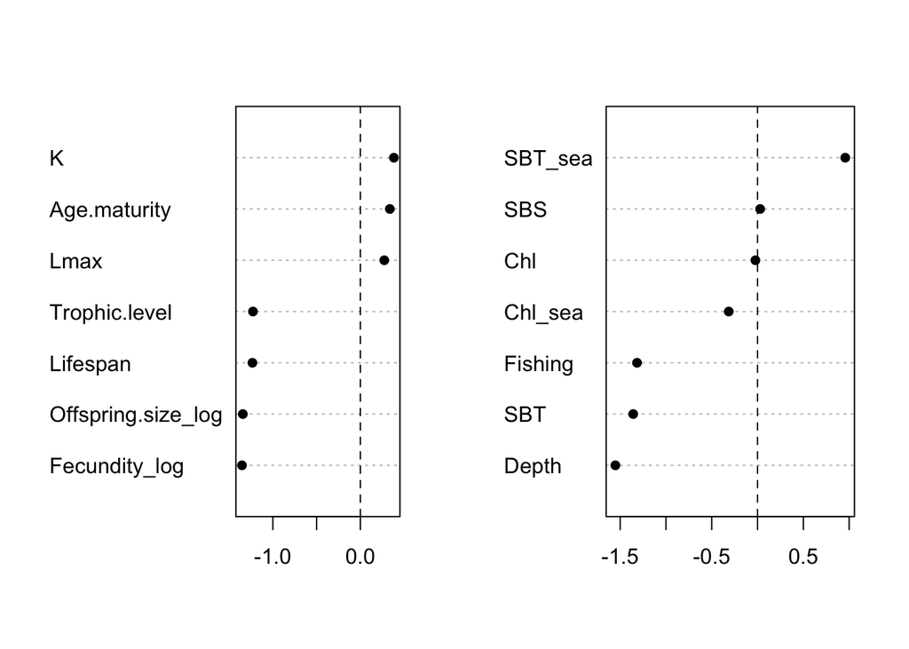

```r
par(mfrow=c(1,2))
t2 <- order(dccaF$C1[,2])
dotchart(dccaF$C1[t2,2], pch=16,
         labels = names(trait)[t2])
abline(v=0, lty=2)

e2 <- order(dccaF$B1[,2])
dotchart(dccaF$B1[e2,2], pch=16,
         labels = names(env)[e2])
abline(v=0, lty=2)
```

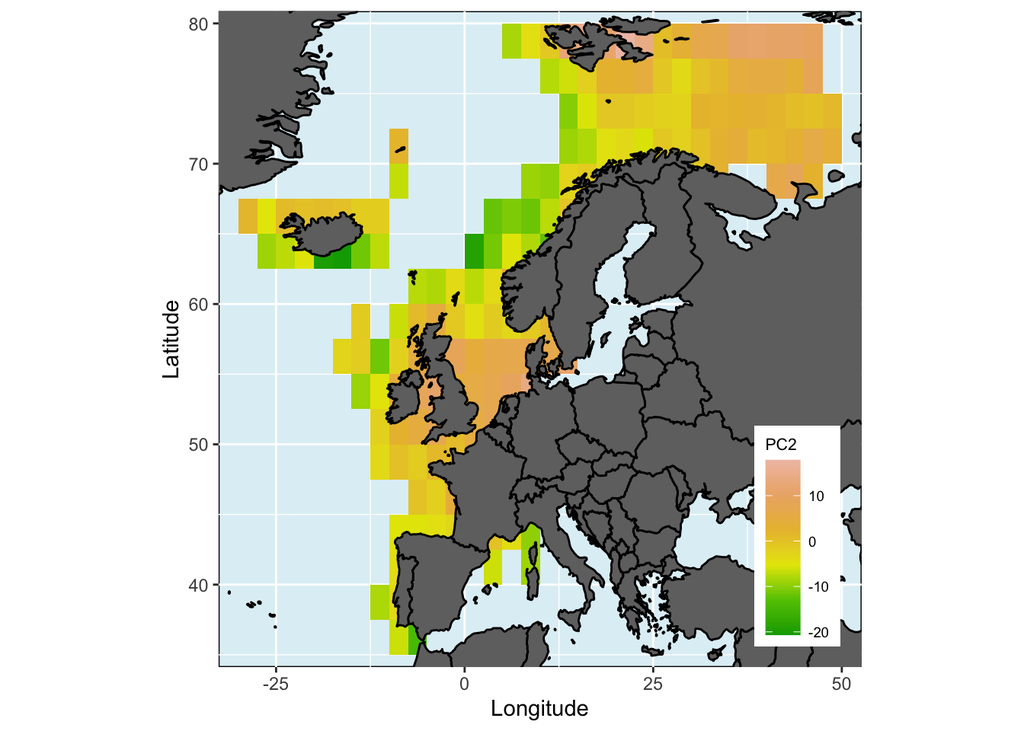

```r
mapggplot(coo[,1], coo[,2], dccaF$X[,2],
          colpal, main="PC2")
```

# 2. Stepwize analysis

DC-CA is computed in 4 steps:

1. CCA(Y ~ Env)
2. Weighted RDA(S*~Traits)
3. CCA(t(Y) ~Traits)
4. Weighted RDA(R*~Env)

### 2.1. CCA of the community table on to the environmental variables

```r
#step 1. CCA(Y ~ Env)
CA_on_Abun <- dudi.coa(abu, scannf = F)
Step1_CCA_on_env <- pcaiv(CA_on_Abun, env, scannf = F, nf = ncol(env)) # CCA1

S_star <- Step1_CCA_on_env$co

dim(S_star)
```

```
## [1] 148   7
```

```r
q_star <- ncol(S_star)
p_star <- qr(model.matrix(~ as.matrix(trait)))$rank-1
```

From this analysis, we obtain an m × q* table of scores (called S* ) with q* the rank of the environmental data(=number of environmental variables if they are of full rank). By definition, S* contains species-niche centroids (SNC) with respect to orthonormalized environmental variables.

#### Summary of Step 1: CCA(Y ~ Env)

Eigenvalues of CCA of abundance table on Env (canonical eigenvalues)

```r
# the eigenvalues of CCA of Y on Env (canonical eigenvalues)
Exp_var_by_Env <- sum(Step1_CCA_on_env$eig)/sum(CA_on_Abun$eig)
# % variation in the abundance values
#   explained by the environmental variables
Exp_var_by_Env
```

```
## [1] 0.371405
```

Percent variation in abundances explained by the Environmental variables

```r
#R2 =
round(100*Exp_var_by_Env,2)
```

```
## [1] 37.14
```

```r
# adjusted R2
Step1_adjR2 <- adj_R2(cumsum(Step1_CCA_on_env$eig)/sum(CA_on_Abun$eig),
                      n = nrow(env), df = Step1_CCA_on_env$rank)
names(Step1_adjR2)<- paste("Axis", seq_len(Step1_CCA_on_env$rank))

#adj R2 =
round(100* adj_R2(Exp_var_by_Env, n = nrow(env), df = Step1_CCA_on_env$rank),2)
```

```
## [1] 34.41
```

Cumulatively across axes

```r
round(100* Step1_adjR2,2)
```

```
## Axis 1 Axis 2 Axis 3 Axis 4 Axis 5 Axis 6 Axis 7
##  12.22  20.60  25.94  29.89  32.39  33.58  34.41
```

### 2.2. an RDA of S* on the trait variables using species weights

step 2. Weighted RDA(S* ~Traits): an RDA of S* on the trait variables, using species weights K = colSums(Y) or K/sum(K), given by Step1_CCA_on_env$cw

```r
# weighted RDA(S*~Traits):
pca_S_star <- dudi.pca(S_star, row.w = Step1_CCA_on_env$cw,
                       scale = FALSE, scannf = FALSE, nf = ncol(S_star))
Step2_wrRDA_SNC_on_Traits <- pcaiv(pca_S_star, trait, scannf = FALSE,
                                   nf = ncol(trait))
```

It is of interest to express these eigenvalues as fraction of the environmentally structured variation which was obtained in step 1. The fraction of environmentally structured variation explained by the traits is

```r
R2_Env_variation_explained_by_Traits <- sum(Step2_wrRDA_SNC_on_Traits$eig)/sum(Step1_CCA_on_env$eig)
R2_Env_variation_explained_by_Traits
```

```
## [1] 0.1484754
```

```r
# per axis
Fraction_env_structured_variation_explained_by_traits <- cumsum(Step2_wrRDA_SNC_on_Traits$eig)/sum(Step1_CCA_on_env$eig) #
names_axes <- paste("Axis",seq_along(Step2_wrRDA_SNC_on_Traits$eig))
names(Fraction_env_structured_variation_explained_by_traits)<- names_axes
Fraction_env_structured_variation_explained_by_traits
```

```
##     Axis 1     Axis 2     Axis 3     Axis 4     Axis 5     Axis 6     Axis 7
## 0.06628098 0.11145332 0.13600288 0.14297893 0.14765318 0.14822702 0.14847536
```

```r
# Species-level significance test
nrepet <- 999  # number of permutations in tests
Species_level_test <- randtest(Step2_wrRDA_SNC_on_Traits, nrepet = nrepet)
Species_level_test
```

```
## Monte-Carlo test
## Call: randtest.pcaiv(xtest = Step2_wrRDA_SNC_on_Traits, nrepet = nrepet)
##
## Observation: 0.1484754
##
## Based on 999 replicates
## Simulated p-value: 0.09
## Alternative hypothesis: greater
##
##      Std.Obs  Expectation     Variance
## 1.3846726312 0.1098936137 0.0007763715
```

```r
p_value_species_level_test <- Species_level_test$pvalue
```

Traits and species plots

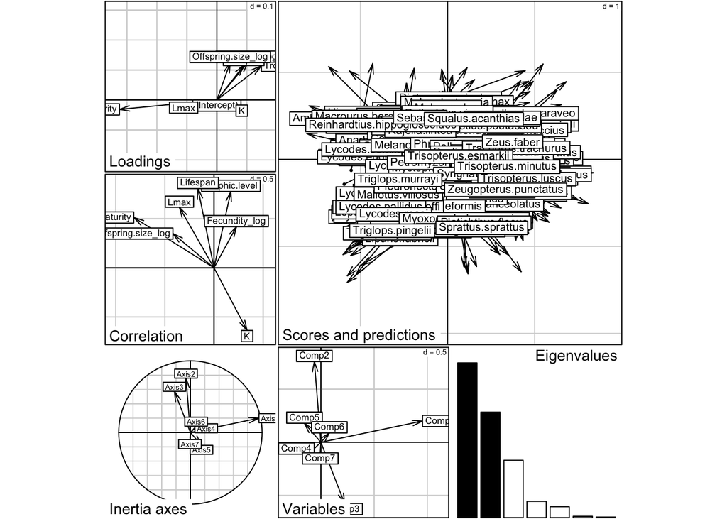

```r
plot(Step2_wrRDA_SNC_on_Traits)
```

```r
# Step1_CCA_on_env$li
# Step2_wrRDA_SNC_on_Traits
```

#### Summary of Step 2: weighted RDA(SNC~Traits

Environmentally structured variation explained by traits

```r
#R2 =
round(100*R2_Env_variation_explained_by_Traits,1)
```

```
## [1] 14.8
```

```r
#adj R2 =
round(100* adj_R2(R2_Env_variation_explained_by_Traits, n = nrow(S_star), df = p_star),2)
```

```
## [1] 10.59
```

Cumulatively across axes

```r
adpa1 <- adj_R2(Fraction_env_structured_variation_explained_by_traits, n = nrow(S_star), df = p_star)
names(adpa1)<- names_axes
round(100* adpa1,2)
```

```
## Axis 1 Axis 2 Axis 3 Axis 4 Axis 5 Axis 6 Axis 7
##   1.96   6.70   9.28  10.01  10.50  10.56  10.59
```

Ratio of double (T,E) vs single (E) constrained eigenvalues (efficiency of the traits to explain the environmentally structured variation)

```r
# Trait efficiencies of environmentally structured variation:
# expressing how well do the traits explain the environmentally structured variation
eff1 <- Step2_wrRDA_SNC_on_Traits$eig/Step1_CCA_on_env$eig[seq_along(Step2_wrRDA_SNC_on_Traits$eig)]
names(eff1)<- names_axes
print(round(eff1,2))
```

```
## Axis 1 Axis 2 Axis 3 Axis 4 Axis 5 Axis 6 Axis 7
##   0.16   0.21   0.18   0.07   0.07   0.02   0.01
```

P-value of the species-level test in dc-CA

```r
p_value_species_level_test
```

```
## [1] 0.09
```

### 2.3 CCA of the transposed community table on to the traits

Step 3. CCA(t(Y) ~Traits): a CCA of the transposed community table on to the traits

```r
# the standard way of doing a CCA in ade4:
CA_on_Abun.t <- dudi.coa(t(abu), scannf = F)
Step3_CCA_on_traits <- pcaiv(CA_on_Abun.t, trait, scannf = F, nf = ncol(trait))

# the CCA eigenvalues (canonical eigenvalues)
Step3_CCA_on_traits$eig
```

```
## [1] 0.14991191 0.12248441 0.08010310 0.04817404 0.02919052 0.02713880 0.01680723
```

```r
R_star <- Step3_CCA_on_traits$co
dim(R_star)
```

```
## [1] 169   7
```

```r
# p_star <- qr(model.matrix(~ as.matrix(trait)))$rank-1
```

We obtain from this analysis an n × p* table of scores (called R* ) with p* the rank of the trait data (=number of traits if traits are of full rank). By definition, R* contains community-weighted means (CWM) with respect to orthonormalized trait variables.

#### Summary of Step 3: CCA(t(Y) ~ Traits)

Eigenvalues of CCA of the transposed abundance table on to the traits (canonical eigenvalues)

```r
round(Step3_CCA_on_traits$eig,3)
```

```
## [1] 0.150 0.122 0.080 0.048 0.029 0.027 0.017
```

Percent variation in abundances explained by the traits

```r
Exp_var_by_Traits <- sum(Step3_CCA_on_traits$eig)/sum(CA_on_Abun.t$eig)
# % variation in the abundance values
#   explained by the traits
round(100*Exp_var_by_Traits,2)
```

```
## [1] 11.04
```

```r
Step3_adjR2 <- adj_R2(cumsum(Step3_CCA_on_traits$eig)/sum(CA_on_Abun$eig),
                      n = nrow(trait), df = Step3_CCA_on_traits$rank)
names(Step3_adjR2)<- paste("Axis", seq_len(Step3_CCA_on_traits$rank))

# adjR2 =
round(100* adj_R2(Exp_var_by_Traits, n = nrow(trait), df = Step3_CCA_on_traits$rank),2)
```

```
## [1] 6.59
```

```r
# Cumulatively across axes:
print(round(100* Step3_adjR2,2))
```

```
## Axis 1 Axis 2 Axis 3 Axis 4 Axis 5 Axis 6 Axis 7
##  -1.33   1.66   3.62   4.80   5.51   6.18   6.59
```

### 2.4. RDA of R* on the environmental variables

Step 4. Weighted RDA(R* ~Env): an RDA of R* on the environmental variables, using sample weights R = rowSums(Y) or R/sum(R), given by Step1_CCA_on_env$lw.

```r
# weighted RDA(R*~Env)
pca_R_star <- dudi.pca(R_star, row.w = Step1_CCA_on_env$lw, scale = FALSE,
                       scannf = FALSE, nf = ncol(R_star))
Step4_wRDA_CWM_on_Env <- pcaiv(pca_R_star, env, scannf = FALSE,
                               nf = ncol(env))
```

Note that the eigenvalues of this weighted RDA are equal to the dc-CA eigenvalues

```r
abs(Step4_wRDA_CWM_on_Env$eig - Step2_wrRDA_SNC_on_Traits$eig)<1.e-12
```

```
## [1] TRUE TRUE TRUE TRUE TRUE TRUE TRUE
```

```r
eig24 <- rbind(Step2_wrRDA_SNC_on_Traits$eig, Step4_wRDA_CWM_on_Env$eig)
rownames(eig24) <- paste("eigenvalues step ", c(2,4))
colnames(eig24) <- names_axes
```

It is of interest to express these eigenvalues as fraction of the trait structured variation which was obtained in step 3. The fraction of trait-structured variation explained by the environmental variables is thus

```r
Step4_wRDA_CWM_on_Env$eig/sum(Step3_CCA_on_traits$eig) #
```

```
## [1] 0.2230776636 0.1520336514 0.0826248799 0.0234788126 0.0157318330
## [6] 0.0019313407 0.0008358283
```

```r
R2_Trait_variation_explained_by_Env <- sum(Step4_wRDA_CWM_on_Env$eig)/sum(Step3_CCA_on_traits$eig)
# expressed as percentage
round(100*R2_Trait_variation_explained_by_Env,1)
```

```
## [1] 50
```

```r
Fraction_trait_structured_variation_explained_by_env <- cumsum(Step4_wRDA_CWM_on_Env$eig)/sum(Step3_CCA_on_traits$eig) #
names(Fraction_trait_structured_variation_explained_by_env)<- names_axes
Fraction_trait_structured_variation_explained_by_env
```

```
##    Axis 1    Axis 2    Axis 3    Axis 4    Axis 5    Axis 6    Axis 7
## 0.2230777 0.3751113 0.4577362 0.4812150 0.4969468 0.4988782 0.4997140
```

```r
# sample-level test
Sample_level_test <- randtest(Step4_wRDA_CWM_on_Env, nrepet = nrepet)
Sample_level_test
```

```
## Monte-Carlo test
## Call: randtest.pcaiv(xtest = Step4_wRDA_CWM_on_Env, nrepet = nrepet)
##
## Observation: 0.499714
##
## Based on 999 replicates
## Simulated p-value: 0.001
## Alternative hypothesis: greater
##
##      Std.Obs  Expectation     Variance
## 4.585014e+01 4.228921e-02 9.953092e-05
```

```r
p_value_sample_level_test <- Sample_level_test$pvalue
```

Environmental variables and sample plots:

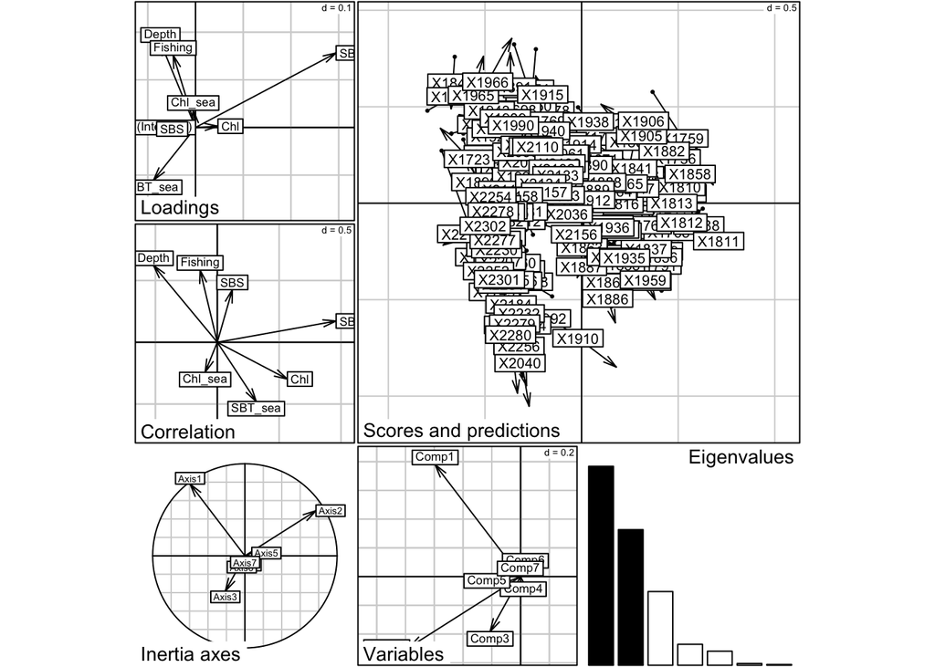

```r
plot(Step4_wRDA_CWM_on_Env)
```

#### Summary of Step 4: weighted RDA(CWM~Env)

dc-CA eigenvalues obtained in step 2 and 4 are equal(and equal to those of the single SVD)

```r
eig24
```

```
##                        Axis 1     Axis 2    Axis 3    Axis 4    Axis 5
## eigenvalues step  2 0.1056964 0.07203507 0.0391485 0.0111245 0.0074539
## eigenvalues step  4 0.1056964 0.07203507 0.0391485 0.0111245 0.0074539
##                           Axis 6       Axis 7
## eigenvalues step  2 0.0009150886 0.0003960238
## eigenvalues step  4 0.0009150886 0.0003960238
```

Fourth-corner correlations between the dc-CA sample and species axes

```r
sqrt(eig24[1,])
```

```
##     Axis 1     Axis 2     Axis 3     Axis 4     Axis 5     Axis 6     Axis 7
## 0.32510988 0.26839349 0.19785979 0.10547273 0.08633597 0.03025043 0.01990035
```

Trait-structured variation explained by the environmental variables

```r
# R2=
round(100*R2_Trait_variation_explained_by_Env,1)
```

```
## [1] 50
```

```r
# adj R2 =
round(100* adj_R2(R2_Trait_variation_explained_by_Env, n = nrow(R_star), df = q_star),2)
```

```
## [1] 47.8
```

```r
# Cumulatively across axes:
adpa2 <- adj_R2(Fraction_trait_structured_variation_explained_by_env, n = nrow(R_star), df = q_star)
names(adpa2)<- names_axes
round(100* adpa2,2)
```

```
## Axis 1 Axis 2 Axis 3 Axis 4 Axis 5 Axis 6 Axis 7
##  18.93  34.79  43.42  45.87  47.51  47.71  47.80
```

Environmental efficiencies of trait-structured variation: expressing how well do the environmental variable explain the trait structured variation.

Ratio of double (T,E) vs single (T) constrained eigenvalues (efficiency of the environmental variables to explain the trait-structured variation)

```r
eff2 <- Step4_wRDA_CWM_on_Env$eig/Step3_CCA_on_traits$eig[seq_along(Step4_wRDA_CWM_on_Env$eig)]
names(eff2)<-names_axes
round(eff2,2)
```

```
## Axis 1 Axis 2 Axis 3 Axis 4 Axis 5 Axis 6 Axis 7
##   0.71   0.59   0.49   0.23   0.26   0.03   0.02
```

P-value of the sample-level test in dc-CA

```r
p_value_sample_level_test
```

```
## [1] 0.001
```

### 2.5 Summary of the DC-CA

```r
eig <- Step2_wrRDA_SNC_on_Traits$eig
rFC <- sqrt(eig)
Chessels_correlation_ratio <- sqrt(Step2_wrRDA_SNC_on_Traits$eig/CA_on_Abun$eig[seq_along(Step2_wrRDA_SNC_on_Traits$eig)])
Explained_variance =  cumsum(Step2_wrRDA_SNC_on_Traits$eig)/sum(CA_on_Abun$eig)
Explained_fitted_variation_cumulative <- cumsum(Step2_wrRDA_SNC_on_Traits$eig)/sum(Step2_wrRDA_SNC_on_Traits$eig)
# final p-value
# p_max : maximum of p-values of the sample-level test and species-level test
p_max_dcCA <- max(c(p_value_sample_level_test, p_value_species_level_test))


summary_dcCA <- rbind(eig, rFC, Chessels_correlation_ratio,100*Explained_variance,100*Explained_fitted_variation_cumulative,
                      100*adpa2,100*adpa1,eff2,eff1,Chessels_correlation_ratio^2)
rownames(summary_dcCA) <- c(" 1 dc-CA eigenvalues"," 2 fourth-corner correlations (rFC)", " 3 Chessel's correlation ratio",
                            " 4 % Explained variance (cum.)", " 5 % Explained fitted variation (cum.)",
                            " 6 % CWM variation expl. by E (adj R2)",
                            " 7 % SNC variation expl. by T (adj R2)",
                            " 8 Efficiency of extra E constraint",
                            " 9 Efficiency of extra T constraint",
                            "10 Efficiency of (T,E) vs no constraint")

summary_dcCA[,1:3]
```

```
##                                             Axis 1      Axis 2      Axis 3
##  1 dc-CA eigenvalues                     0.1056964  0.07203507  0.03914850
##  2 fourth-corner correlations (rFC)      0.3251099  0.26839349  0.19785979
##  3 Chessel's correlation ratio           0.3827409  0.40670440  0.30833668
##  4 % Explained variance (cum.)           2.4617088  4.13943200  5.05121487
##  5 % Explained fitted variation (cum.)  44.6410666 75.06519887 91.59963223
##  6 % CWM variation expl. by E (adj R2)  18.9298432 34.79422417 43.41595077
##  7 % SNC variation expl. by T (adj R2)   1.9595034  6.70259911  9.28030287
##  8 Efficiency of extra E constraint      0.7050569  0.58811620  0.48872638
##  9 Efficiency of extra T constraint      0.1550603  0.20892843  0.17816484
## 10 Efficiency of (T,E) vs no constraint  0.1464906  0.16540847  0.09507151
```

P-value of dc-CA test: 0.09 (max test:maximum of p-values of the sample-level test and species-level test). Notes:

1: dc-CA eigenvalues are between 0 and 1 2: rFC between constrained sample and species scores 3: Chessel’s fourth-corner correlation or 2 expressed as ratio of maximum (sqrt of CA-eigenvalues) 4: 1 expressed as percentage of the total inertia (weighted variance) 5: 1 expressed as percentage of the total explained inertia 6: Trait-structured variation (CWMs wrt orthonormal traits) explained by the environmental variables 7: Environmentally structured variation (SNCs wrt orthonormal env vars) explained by traits 8: Ratio of double (T,E) vs single (T) constrained eigenvalues (efficiency of the environmental variables to explain the trait-structured variation) 9: Ratio of double (T,E) vs single (E) constrained eigenvalues (efficiency of the traits to explain the environmentally structured variation) 10: Ratio of double (T,E) vs unconstrained (CA) eigenvalues (efficiency of the trait and environmental variables to explain the abundance table; it is the squared Chessels’s correlation ratio

From the single constrained (CCA) analyses: Variation in abundance table (adjusted R2) explained by :

- the environmental variables : 34.41
- traits: 6.59

Note 1: In the above ade4-plots *Loadings* are canonical weights or coefficients that define the species and sample axes of dc-CA.  
*Correlations* are biplot coefficients of the fourth-corner correlations (in compromise scaling) Note 2: Because d=0.5 in the traits and environment *Correlations* plots they form a biplot of the fourth-corner correlations between the traits and the environmental variables. Note 3: In wRDA(CWM~Env), CWM is with respect to orthonormalized traits  
Note 4: In wRDA(SNC~Traits), SNC is with respect to orthonormalized environmental variables.

# References

Peng, F. J., Ter Braak, C. J., Rico, A., & Van den Brink, P. J. (2021). Double constrained ordination for assessing biological trait responses to multiple stressors: A case study with benthic macroinvertebrate communities. Science of the Total Environment, 754, 142171.